# Parekh paper figures

## Code to process Parekh paper data

This code is assembled to perform the steps to summarize differentially expressed genes and clusters of cells. The processed data were downloaded and saved in `SEUSS_processed_data`.

This cade has been pulled from https://github.com/yanwu2014/SEUSS-Analysis and specifically copied from `hESC_summarize_results.R`

The data for cells cultured in the pluripotent stem cell medium has been put into a compressed file in the Google Drive. You should be able to download it from the following link: https://drive.google.com/open?id=19qHsRFO4QwHhotxuw73MYRHB8CFYPM3c and extract the files onto your local computer. You will also need to change the `file.handle` appropriately (see below).

#### Summary of steps to be run

Set the `file.handle` parameter to the name of the sample to be analyzed (this can include `path` information if data not in the same directory as this file). Generate a summary table for each sample, as well as cluster enrichment heatmaps, tSNE plots, and differential expression barplots.

The `hESC_run_regression.R` and `hESC_run_clustering.R` must have been run on the sample first. (This has already been done by Parekh et al.)

#### Step 1

Load all required libraries.

```r
#### Create t-SNE plots, differential expression heatmaps, and cluster enrichment heatmaps
library(perturbLM)
library(swne)
library(ggplot2)
library(RColorBrewer)
library(Seurat)
library(grid)
library(gtable)
```

#### Step 2

Define file locations and load data. Example below includes path information for my computer. Must be modified to work appropriately on your computer.

```r
## Name of the sample to be analyzed
file.handle <- "Parekh_paper_data/up-tf-stem"
#file.handle <- "up-tf-stem"
# file.handle <- "up-tf-endo"
# file.handle <- "up-tf-multi"
# file.handle <- "up-tf-klf"
# file.handle <- "up-tf-myc"
# file.handle <- "up-tf-neuron-nohygro"
## Load regression results
coefs.df <- read.table(paste(file.handle, "regression.pvals.tsv", sep = "_"), sep = "\t",
                       header = T, stringsAsFactors = F)
top.coefs.df <- subset(coefs.df, FDR < 0.05 & abs(cf) > 0.025)
print(sort(table(top.coefs.df$Group), decreasing = T))
```

```
            KLF4             CDX2            SNAI2          ONECUT1             MYOG
             487              272              226              132              122
           ASCL1          NEUROD1            MYOD1             TBX5              MYC
             121              112              101               55               50
           HNF1A            RUNX1          NEUROG3            ASCL4            MESP1
              47               45               44               39               36
         NEUROG1             LHX3            ASCL3             OTX2             SPI1
              35               33               31               30               28
          TFAP2C             SOX2             PAX7            FOXA3            ASCL5
              27               23               22               20               19
             CRX            HAND2            HOXA1             SPIC             SOX3
              18               18               18               17               16
           FOXA2            SOX10           HOXA11           POU1F1            GATA4
              15               15               14               13               12
            SIX2             ETV2            ESRRG            GATA2            HOXB6
              11                9                6                6                5
            SPIB            GATA1            MEF2C             MITF             SIX1
               4                3                3                3                3
             ERG           HOXA10            LMX1A mCherry-int-ctrl             MYCL
               2                2                2                2                2
             SRY             ATF7            FOXP1              NRL
               2                1                1                1
```

```r
## Load clustering
r <- readRDS(paste(file.handle, "clustering.Robj", sep = "_"))
clusters <- r@ident; names(clusters) <- r@cell.names;
levels(clusters) <- paste("C", levels(clusters), sep = "")
clusters.list <- UnflattenGroups(clusters)
## Load genotypes
# genotypes.list <- ReadGenotypes("up-tf-klf-myc_pheno_dict.csv")
genotypes.list <- ReadGenotypes(paste(file.handle, "pheno_dict.csv", sep = "_"))
genotypes.list <- lapply(genotypes.list, function(x) x[x %in% names(clusters)])
genotypes.sizes <- sapply(genotypes.list, length)
```

#### Step 3

Calculate enrichment scores and summarize results.

```r
##  Calculate genotype enrichment
genotypes.cl.tbl <- GenotypeClusterCounts(genotypes.list, clusters.list)
genotypes.cl.pvals <- GenotypeClusterPvals(genotypes.cl.tbl)
genotypes.min.p <- apply(genotypes.cl.pvals, 1, function(x) min(abs(x)) * length(x))
metap::sumlog(genotypes.min.p)
```

```
Some studies omitted
```

```
chisq =  3750.279  with df =  118  p =  0
```

```r
## Summarize analysis results
genotype.counts <- sort(table(top.coefs.df$Group), decreasing = T)
genotype.counts <- genotype.counts[names(genotype.counts) %in% rownames(genotypes.cl.pvals)]
genotype.avg_cf <- tapply(top.coefs.df$cf, top.coefs.df$Group, function(x) mean(abs(x)))[names(genotype.counts)]
genotype.summary <- data.frame(n_diff_genes = as.integer(genotype.counts), avg_cf = genotype.avg_cf)
genotype.summary$min_cluster_pval <- apply(genotypes.cl.pvals[rownames(genotype.summary), ], 1, function(x) min(abs(x)))
genotype.summary$min_cluster <- apply(genotypes.cl.pvals[rownames(genotype.summary), ], 1, function(x) names(x[which.min(abs(x))]))
genotype.summary$n_cells <- genotypes.sizes[rownames(genotype.summary)]
```

#### Step 4

Continue processing to identify significant genotypes.

```r
## Determine significant genotypes
min.cl.pval <- 1e-12
min.diff.genes <- 40
ctrl.cl <- genotype.summary["mCherry", "min_cluster"]
sig.genotypes <- rownames(subset(genotype.summary, (abs(min_cluster_pval) < min.cl.pval & min_cluster != ctrl.cl)
                                 | n_diff_genes > min.diff.genes))
sig.genotypes <- sort(unique(c(sig.genotypes, "mCherry-int-ctrl")), decreasing = T); print(sig.genotypes);
```

```
 [1] "TBX5"             "SNAI2"            "RUNX1"            "ONECUT1"          "NEUROG3"
 [6] "NEUROG1"          "NEUROD1"          "MYOG"             "MYOD1"            "MYC"
[11] "mCherry-int-ctrl" "KLF4"             "HNF1A"            "CDX2"             "ASCL4"
[16] "ASCL1"
```

#### Step 5

Generate barplot graph.

```r
## Differential expression barplot
n.diff.genes <- genotype.summary[sig.genotypes, "n_diff_genes"]
names(n.diff.genes) <- sig.genotypes
gg.bar <- ggBarplot(n.diff.genes, fill.color = "purple")
# pdf(paste(file.handle, "diff_genes_barplot.pdf", sep = "_"), width = 3.5, height = 1.5)
# print(gg.bar)
# dev.off()
## Cluster enrichment heatmap (Figure 1c-e)
max.lp <- 50
genotypes.cl.lp <- apply(genotypes.cl.pvals[sig.genotypes,], 1:2, function(x) ifelse(x > 0, -log10(x), log10(-1 * x)))
genotypes.cl.lp[genotypes.cl.lp > max.lp] <- max.lp
genotypes.cl.lp[genotypes.cl.lp < -1 * max.lp] <- -1 * max.lp
# pdf(paste(file.handle, "cl_enrich_heatmap.pdf", sep = "_"), width = 4.5, height = 5)
# ggHeat(genotypes.cl.lp, clustering = "none", x.lab.size = 14, y.lab.size = 14)
# dev.off()
gg.heat <- ggHeat(t(genotypes.cl.lp), clustering = "none", x.lab.size = 14, y.lab.size = 14)
gg.bar <- gg.bar + theme(axis.text.x = element_blank())
gg.heat <- gg.heat + theme(legend.position = "none")
gg.1 <- ggplotGrob(gg.heat)
gg.2 <- ggplotGrob(gg.bar)
gg.aligned <- rbind(gg.2, gg.1, size = "first")
gg.aligned$widths <- grid::unit.pmax(gg.1$widths, gg.2$widths)
#pdf(paste(file.handle, "stacked_diff_genes_cl_enrich_nolabels.pdf", sep = "_"), width = 5.5, height = 6)
grid::grid.newpage()
```

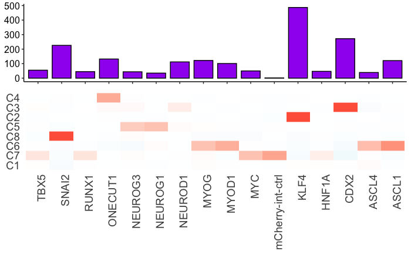

```r
grid::grid.draw(gg.aligned)
```

```r
#dev.off()
```

#### Step 6

Generate tSNE plots

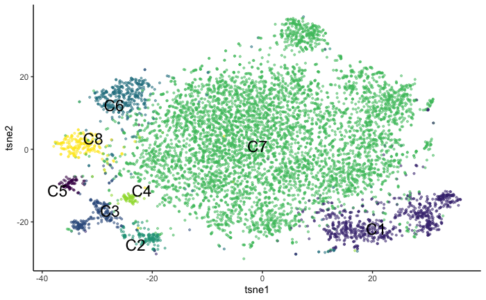

```r
## tSNE plots (Figure 1c-e)
plot.seed <- 32907098
tsne.emb <- GetCellEmbeddings(r, reduction.type = "tsne")
#pdf(paste(file.handle, "tsne_plot.pdf", sep = "_"), width = 4, height = 4)
PlotDims(tsne.emb, sample.groups = clusters, pt.size = 0.75, alpha.plot = 0.5, label.size = 6, do.label = T,
         show.legend = F, seed = plot.seed)
```

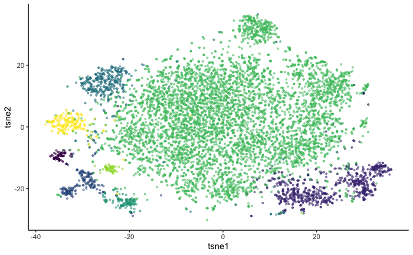

```r
#dev.off()
#pdf(paste(file.handle, "tsne_plot_nolabel.pdf", sep = "_"), width = 4, height = 4)
PlotDims(tsne.emb, sample.groups = clusters, pt.size = 0.75, alpha.plot = 0.5, label.size = 0, do.label = F,
         show.legend = F, seed = plot.seed)
```

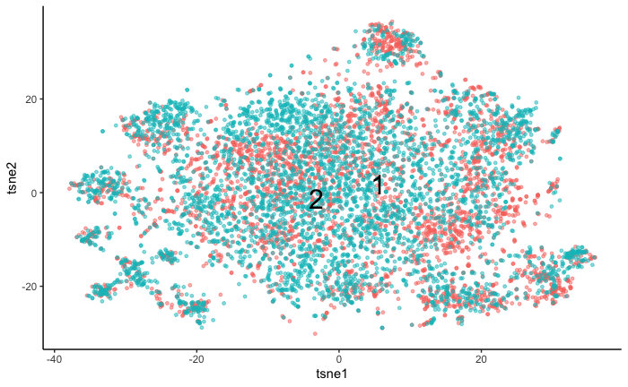

```r
#dev.off()
#pdf(paste(file.handle, "tsne_plot_batch.pdf", sep = "_"), width = 4, height = 4)
batch <- factor(r@meta.data$batch); names(batch) <- r@cell.names; batch <- batch[rownames(tsne.emb)];
PlotDims(tsne.emb, sample.groups = batch, pt.size = 1, alpha.plot = 0.5, label.size = 8, do.label = T,
         show.legend = F, seed = plot.seed)
```

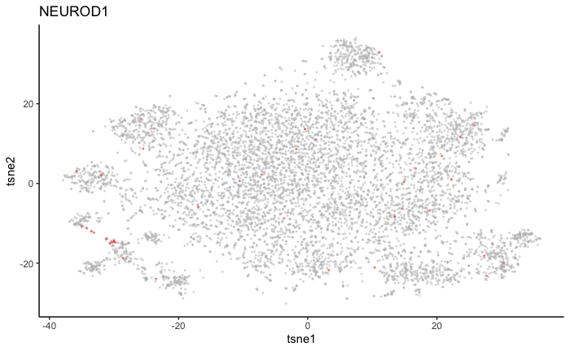

```r
#dev.off()
## tSNE plot overlay
plot.seed <- 32907098
tsne.emb <- GetCellEmbeddings(r, reduction.type = "tsne")
TF <- "NEUROD1"
tf.groups <- as.character(clusters); names(tf.groups) <- names(clusters);
tf.groups[names(tf.groups) %in% genotypes.list[[TF]]] <- TF
tf.groups[!names(tf.groups) %in% genotypes.list[[TF]]] <- ""
tf.groups <- factor(tf.groups)
#pdf(paste0(file.handle, "_tsne_plot_", TF, ".pdf"), width = 3, height = 3)
PlotDims(tsne.emb, sample.groups = tf.groups, pt.size = 0.35, alpha.plot = 0.4, label.size = 0, do.label = T,
         show.legend = F, seed = plot.seed) + scale_color_manual(values = c("grey", "red")) + ggtitle(TF)
```

```r
#dev.off()
```